# Examining Differential Gene Expression in *Strongylocentrotus purpuratus* Under Upwelling vs. Non-upwelling Conditions

Victoria French, Madison Pacaro & Jamie Poirier

# Introduction

For this assignment, we used data presented in [“Examining the Role of DNA Methylation in Transcriptomic Plasticity of Early Stage Sea Urchins: Developmental and Maternal Effects in a Kelp Forest Herbivore”](https://www.frontiersin.org/articles/10.3389/fmars.2020.00205/full) by M. Strader et al. (2020) in Frontiers in Marine Science.

In Strader et al.’s work, they explored the relationship between the dynamics of gene expression and the effects of epigenetic markers. It considers the extent of environmental effects on plasticity both within and between generations of sea urchins. They worked with Stronglyocentrotus purpuratus and simulated both upwelling and non-upwelling conditions, and examined connections in changes regarding DNA methylation, transcription, and spicule length of their offspring during embryonic development.

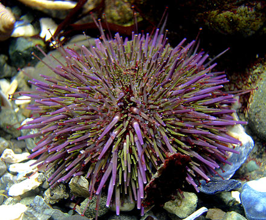

*Strongylocentrotus purpuratus*

Figure 1: *Stronglyocentrotus purpuratus*: photo via. Wikipedia (Kirt L. Onthank)

In their analysis, they used reduced representation bisulfite sequencing (RRBS) sequencing, pre-processing and analysis, which is a high-throughput technique used for analysis of methylation within a genome. Following this, they used RNA sequencing as well as differential gene expression analysis and weighted gene co-expression network analysis (WGCNA), which is used for the correlation and clustering of genes.

They ultimately found that forms of genetic environmentally induced plasticity are similar within groups of genes, but on an individual level, these changes were largely unique. It also found that there were significant differences in methylation of CpG sites and gene expression based on maternal conditioning, and environmental conditions during embryonic development had a significant effect on spicule length.

# Version Control

R version 4.0.3 was used for all analyses.

DESeq2 package version 1.30.1

affycoretools package version 1.62.0

arrayQualityMetrics package version 3.46.0

genefilter package version 1.72.1

Biobase package version 2.50.0

dplyr package version 1.0.5

RColorBrewer package version 1.1-2

gplots package version 3.1.1

vegan package version 2.5-7

ggplot 2 package version 3.3.3

ggrepel package version 0.9.1

tidyverse package version 1.3.0

pheatmap package version 1.0.12

go.obo version 1.2

# Data Analysis & Methods

First, we loaded all the required packages for our analyses.

```r
library(DESeq2)
library(affycoretools)
library(arrayQualityMetrics)
library(genefilter)
library(Biobase)
library(dplyr)
library(RColorBrewer)
library(gplots)
library(vegan)
library(ggplot2)
library(ggrepel)
library(tidyverse)
library(pheatmap)
```

We then set our working directory for the project.

```r
setwd("C:/Users/Maddy/Documents/BI586/seaurchinupwelling")
```

Next, we read in our raw count data, and determined the length of the data.

```r
countData <- read.table("geneCounts_02122019.txt")
head(countData)
```

```
##                 NN1 NN2 NN3 UU1 UU2 UU3
## SPU_016802        1   0   0   0   0   0
## SPU_001114        2   3   5   0   1   0
## SPU_017127        0   0   3   1   1   0
## SPU_017128      281 227 277 218 165 111
## ENSRNA022746508   0   0   0   2   0   0
## SPU_023838        4   4   3   1   2   2
```

```r
length(countData[,1])
```

```
## [1] 30284
```

The length of our data is 30284. This is the number of genes we have represented in our data set.

We then remaned our data by our two treatments: NN = non-upwelling and UU = upwelling conditions.

```r
names(countData)=c("NN", "NN", "NN", "UU", "UU", "UU")
head(countData)
```

```
##                  NN  NN  NN  UU  UU  UU
## SPU_016802        1   0   0   0   0   0
## SPU_001114        2   3   5   0   1   0
## SPU_017127        0   0   3   1   1   0
## SPU_017128      281 227 277 218 165 111
## ENSRNA022746508   0   0   0   2   0   0
## SPU_023838        4   4   3   1   2   2
```

# Outlier Analysis

We conducted array quality metrics to detect and remove outliers in our data and specified the directory for outlier data.

```r
v=setwd("C:/Users/Maddy/Documents/BI586/seaurchinupwelling")
treat=c("NN", "NN", "NN", "UU", "UU", "UU")
```

Here, we are creating colData, which is a data frame associating sample with treatment.

```r
g=data.frame(treat)
colData=g
colData
```

```
##   treat
## 1    NN
## 2    NN
## 3    NN
## 4    UU
## 5    UU
## 6    UU
```

We now are calling on DESeq2 to create a model for our data, which is storing the results of analysis of differential expression and asking how our design varies by treatment. We then normalized our data.

```r
dds=DESeqDataSetFromMatrix(countData=countData,
                           colData = g,
                           design = ~treat)
vsd.ge=assay(vst(dds))
rl=vst(dds)
```

Using arrayQualityMetrics, we then identified any outliers in our data, which can be seen by clicking the link below. An outlier in UU was detected under “Distances between arrays.” We will be keeping this outlier in our data because it was only offensive in distance between arrays, but not in boxplots or MA plots. Based on the barplot of our total counts data below, we will see even distribution between our treatments, which is another reason we are keeping this outlier.

```r
e=ExpressionSet(assay(rl), AnnotatedDataFrame(as.data.frame(colData(rl))))
arrayQualityMetrics(e,outdir=v,intgroup=c("treat"),force=T)
```

arrayQualityMetrics Report

```r
totalCounts=colSums(countData)

totalCounts
```

```
##      NN      NN      NN      UU      UU      UU
## 8555156 8577700 8948115 8570174 7455015 6376636
```

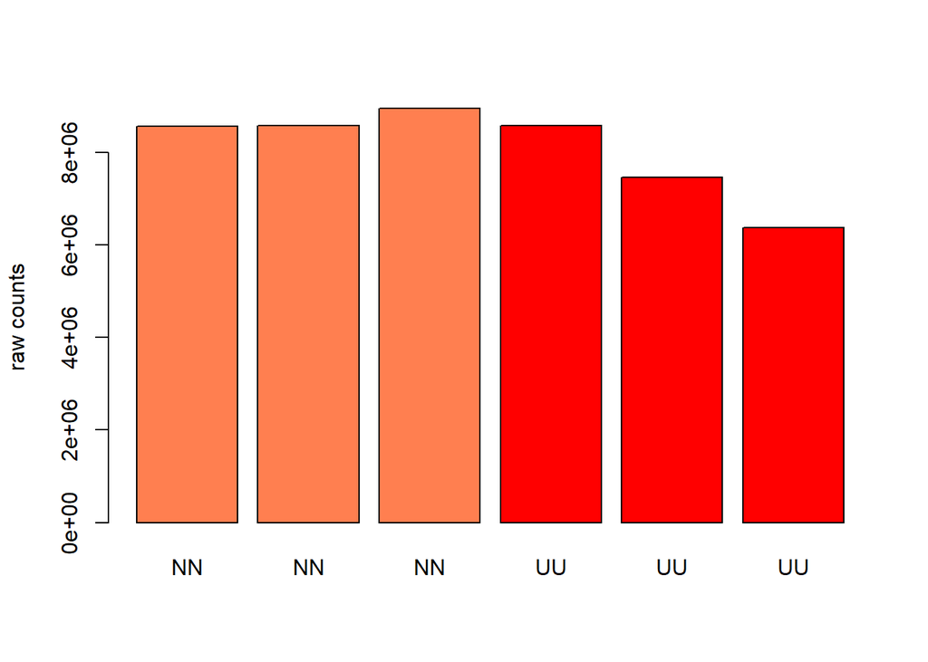

```r
barplot(totalCounts, col=c("coral", "coral", "coral", "red", "red", "red"), ylab="raw counts")
```

```r
min(totalCounts)
```

```
## [1] 6376636
```

```r
max(totalCounts)
```

```
## [1] 8948115
```

We then created the DESeq object and saved the results of the model.

```r
dds<-DESeq(dds)

head(dds)
```

```
## class: DESeqDataSet
## dim: 6 6
## metadata(1): version
## assays(4): counts mu H cooks
## rownames(6): SPU_016802 SPU_001114 ... ENSRNA022746508 SPU_023838
## rowData names(22): baseMean baseVar ... deviance maxCooks
## colnames(6): NN NN ... UU UU
## colData names(2): treat sizeFactor
```

```r
res<- results(dds)
res
```

```
## log2 fold change (MLE): treat UU vs NN
## Wald test p-value: treat UU vs NN
## DataFrame with 30284 rows and 6 columns
##                   baseMean log2FoldChange     lfcSE      stat    pvalue
##                  <numeric>      <numeric> <numeric> <numeric> <numeric>
## SPU_016802        0.149879      -0.619228  4.080473 -0.151754  0.879381
## SPU_001114        1.636986      -2.864600  1.830283 -1.565113  0.117556
## SPU_017127        0.757229      -0.306626  2.495360 -0.122879  0.902203
## SPU_017128      204.147340      -0.365821  0.177524 -2.060686  0.039333
## ENSRNA022746508   0.300953       1.977419  4.055319  0.487611  0.625825
## ...                    ...            ...       ...       ...       ...
## SPU_023900          0.0000             NA        NA        NA        NA
## SPU_007624        240.3216      -0.490580  0.179418 -2.734285 0.0062516
## SPU_007623         98.0816      -0.237049  0.237062 -0.999947 0.3173361
## SPU_019837          0.0000             NA        NA        NA        NA
## SPU_027230          0.0000             NA        NA        NA        NA
##                      padj
##                 <numeric>
## SPU_016802             NA
## SPU_001114             NA
## SPU_017127             NA
## SPU_017128       0.184865
## ENSRNA022746508        NA
## ...                   ...
## SPU_023900             NA
## SPU_007624      0.0504741
## SPU_007623      0.6352307
## SPU_019837             NA
## SPU_027230             NA
```

Then, to look at the dispersion of our data, we plotted a visual representation of the DESeq object. This plot follows the general shape of a hockey stick, which shows that the dispersion fits well to the curve.

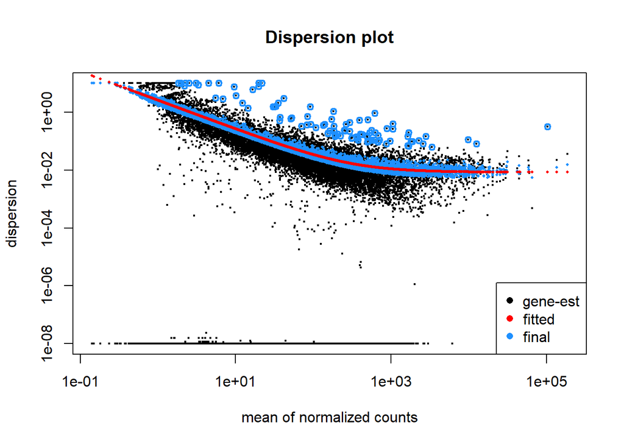

```r
plotDispEsts(dds, main="Dispersion plot")
```

# Treatment Comparisons

Next, I performed analyses to examine differentially expressed genes among our two treatment groups: upwelling vs. non-upwelling. In the first analysis, we specified non-upwelling (NN) as our control in the levels option and our results will therefore be in terms of upwelling compared to non-upwelling.

We looked at signficantly differentially expressed genes in upwelling conditions at verying levels of significance. At the highest confidence level we have 715 differentially expressed genes in upwelling vs. non-upwelling conditions.

```r
colData$UU<-factor(colData$treat, levels=c("UU","NN"))
resUU <- results(dds, contrast=c("treat","UU","NN"))
table(resUU$padj<0.001)
```

```
##
## FALSE  TRUE
## 17824   715
```

```r
# 0.1=3039 - not significant
# 0.05=2289
# 0.01=1344
# 0.001 =715
```

We summarized resUU. This allows us to see that there are genes removed in pairwise analysis due to low counts (23%) and we also see 5.4% of genes were downregulated in UU relative to NN. In addition, 7.2% of genes were upregulated in UU relative to NN.

```r
summary(resUU)
```

```
##
## out of 24063 with nonzero total read count
## adjusted p-value < 0.1
## LFC > 0 (up)       : 1735, 7.2%
## LFC < 0 (down)     : 1304, 5.4%
## outliers [1]       : 2, 0.0083%
## low counts [2]     : 5522, 23%
## (mean count < 2)
## [1] see 'cooksCutoff' argument of ?results
## [2] see 'independentFiltering' argument of ?results
```

Here we are using another method to look at differentially expressed genes, as we did above. We see the number of significantly differentially expressed genes excluding low count genes.

```r
nrow(resUU[resUU$padj<0.05 & !is.na(resUU$padj),])
```

```
## [1] 2289
```

We plotted log fold change by mean of normalized counts to produce a visual representation of differentially expressed genes. We kept the y limits to 4,-4 as anything beyond is extremely differentially expressed.

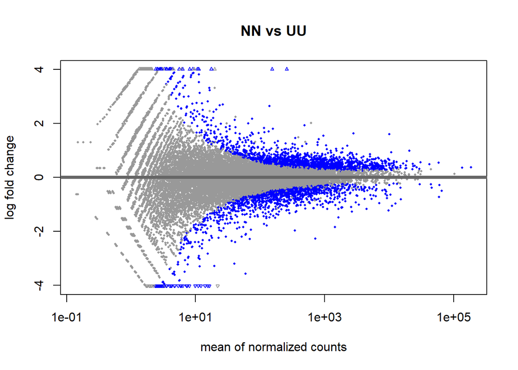

```r
plotMA(resUU, main="NN vs UU")
```

We summarized our results.

```r
results <- as.data.frame(resUU)
head(results)
```

```
##                    baseMean log2FoldChange     lfcSE       stat    pvalue
## SPU_016802        0.1498786     -0.6192280 4.0804729 -0.1517540 0.8793810
## SPU_001114        1.6369857     -2.8646005 1.8302830 -1.5651135 0.1175563
## SPU_017127        0.7572293     -0.3066263 2.4953604 -0.1228786 0.9022033
## SPU_017128      204.1473396     -0.3658205 0.1775236 -2.0606861 0.0393330
## ENSRNA022746508   0.3009525      1.9774195 4.0553188  0.4876113 0.6258252
## SPU_023838        2.6059104     -0.7634418 1.2575045 -0.6071087 0.5437788
##                      padj
## SPU_016802             NA
## SPU_001114             NA
## SPU_017127             NA
## SPU_017128      0.1848653
## ENSRNA022746508        NA
## SPU_023838      0.8035963
```

Then, we examined upregulated and downregulated genes separately. Upregulated genes are genes with a positive logfold change and downregulated genes are genes with a negative logfold change.

```r
nrow(resUU[resUU$padj<0.1 & resUU$log2FoldChange > 0 & !is.na(resUU$padj),])
```

```
## [1] 1735
```

```r
nrow(resUU[resUU$padj<0.1 & resUU$log2FoldChange < 0 & !is.na(resUU$padj),])
```

```
## [1] 1304
```

```r
#UP in UU is 1735
#DOWN in UU is 1304
```

We created a table to summarize our results from above.

```r
write.table(resUU, file="UU_DEG.txt", quote=F, sep="\t")

cd <- read.table("UU_DEG.txt")
```

We then created a GO table with ranked p-values with directionality for each gene. We then saved the table as a CSV for future GO analysis.

```r
go_input_UU = cd %>%
  tibble::rownames_to_column(var = "iso") %>%
  mutate(mutated_p = -log(pvalue)) %>%
  mutate(mutated_p_updown = ifelse(log2FoldChange < 0, mutated_p*-1, mutated_p*1)) %>%
  na.omit() %>%
  select(iso, mutated_p_updown)

head(go_input_UU)
```

```
##           iso mutated_p_updown
## 4  SPU_017128       -3.2356914
## 6  SPU_023838       -0.6092127
## 7  SPU_010035       -0.1428236
## 9  SPU_001332       -5.1612479
## 10 SPU_010036       -1.4711208
## 13 SPU_001333        1.0702836
```

```r
colnames(go_input_UU) <- c("gene", "pval")
head(go_input_UU)
```

```
##          gene       pval
## 4  SPU_017128 -3.2356914
## 6  SPU_023838 -0.6092127
## 7  SPU_010035 -0.1428236
## 9  SPU_001332 -5.1612479
## 10 SPU_010036 -1.4711208
## 13 SPU_001333  1.0702836
```

```r
write.csv(go_input_UU, file="UU_GO.csv", quote=F, row.names=FALSE)
```

We bound the p-value from res comparisons and the p-adjusted values. We then created a log fold change p-value data table.

```r
valUU=cbind(resUU$pvalue, resUU$padj)
head(valUU)
```

```
##           [,1]      [,2]
## [1,] 0.8793810        NA
## [2,] 0.1175563        NA
## [3,] 0.9022033        NA
## [4,] 0.0393330 0.1848653
## [5,] 0.6258252        NA
## [6,] 0.5437788 0.8035963
```

```r
#this is pvalues and padjusted values
colnames(valUU)=c("pval.UU", "padj.UU")
length(valUU[,1]) #this is the number of genes we are looking at = 30284 (same as above)
```

```
## [1] 30284
```

```r
table(complete.cases(valUU))
```

```
##
## FALSE  TRUE
## 11745 18539
```

```r
#False = NAs
```

Here we are performing r log transformations, which is a normalization method and important for making heat maps and PCAs.

```r
rlog=rlogTransformation(dds, blind=TRUE)
rld=assay(rlog)
head(rld)
```

```
##                         NN         NN         NN         UU         UU
## SPU_016802      -1.9673957 -1.9754138 -1.9756254 -1.9753790 -1.9746116
## SPU_001114       0.7374181  0.7556454  0.7876164  0.6994910  0.7233684
## SPU_017127      -0.3993964 -0.3994176 -0.3458342 -0.3802686 -0.3766433
## SPU_017128       7.8420088  7.6647205  7.7827926  7.6397290  7.5735496
## ENSRNA022746508 -1.4982643 -1.4982983 -1.4986778 -1.4695371 -1.4968593
## SPU_023838       1.3969805  1.3966616  1.3755498  1.3411538  1.3685984
##                         UU
## SPU_016802      -1.9735944
## SPU_001114       0.7042175
## SPU_017127      -0.3971995
## SPU_017128       7.4723371
## ENSRNA022746508 -1.4950345
## SPU_023838       1.3806041
```

```r
#this shows us for each isogroup, the r log normalized values for each of our samples
colnames(rld)=paste(colData$treat)
head(rld)
```

```
##                         NN         NN         NN         UU         UU
## SPU_016802      -1.9673957 -1.9754138 -1.9756254 -1.9753790 -1.9746116
## SPU_001114       0.7374181  0.7556454  0.7876164  0.6994910  0.7233684
## SPU_017127      -0.3993964 -0.3994176 -0.3458342 -0.3802686 -0.3766433
## SPU_017128       7.8420088  7.6647205  7.7827926  7.6397290  7.5735496
## ENSRNA022746508 -1.4982643 -1.4982983 -1.4986778 -1.4695371 -1.4968593
## SPU_023838       1.3969805  1.3966616  1.3755498  1.3411538  1.3685984
##                         UU
## SPU_016802      -1.9735944
## SPU_001114       0.7042175
## SPU_017127      -0.3971995
## SPU_017128       7.4723371
## ENSRNA022746508 -1.4950345
## SPU_023838       1.3806041
```

```r
length(rld[,1]) #length should be still same, indicating retention of all data
```

```
## [1] 30284
```

Now we are binding our rld data and p-values in order to rank p-values for the top 100 heat map we create later on. We then created a CSV file with this information.

```r
rldpvals=cbind(rld,valUU)
head(rldpvals)
```

```
##                         NN         NN         NN         UU         UU
## SPU_016802      -1.9673957 -1.9754138 -1.9756254 -1.9753790 -1.9746116
## SPU_001114       0.7374181  0.7556454  0.7876164  0.6994910  0.7233684
## SPU_017127      -0.3993964 -0.3994176 -0.3458342 -0.3802686 -0.3766433
## SPU_017128       7.8420088  7.6647205  7.7827926  7.6397290  7.5735496
## ENSRNA022746508 -1.4982643 -1.4982983 -1.4986778 -1.4695371 -1.4968593
## SPU_023838       1.3969805  1.3966616  1.3755498  1.3411538  1.3685984
##                         UU   pval.UU   padj.UU
## SPU_016802      -1.9735944 0.8793810        NA
## SPU_001114       0.7042175 0.1175563        NA
## SPU_017127      -0.3971995 0.9022033        NA
## SPU_017128       7.4723371 0.0393330 0.1848653
## ENSRNA022746508 -1.4950345 0.6258252        NA
## SPU_023838       1.3806041 0.5437788 0.8035963
```

```r
dim(rldpvals) #looking at dimensions [1] 30284
```

```
## [1] 30284     8
```

```r
table(complete.cases(rldpvals))
```

```
##
## FALSE  TRUE
## 11745 18539
```

```r
#FALSE  TRUE
#11745  18539 , sanity check: we still have the same number of NAs (false) here

write.csv(rldpvals, "RLDandPVALS.csv", quote=F)
```

Then we created our Sample Distance heat map. Our heat map shows clustering of similar samples by upwelling and non-upwelling conditions, which we expect. This is a good way to visualize overall expression between our samples.

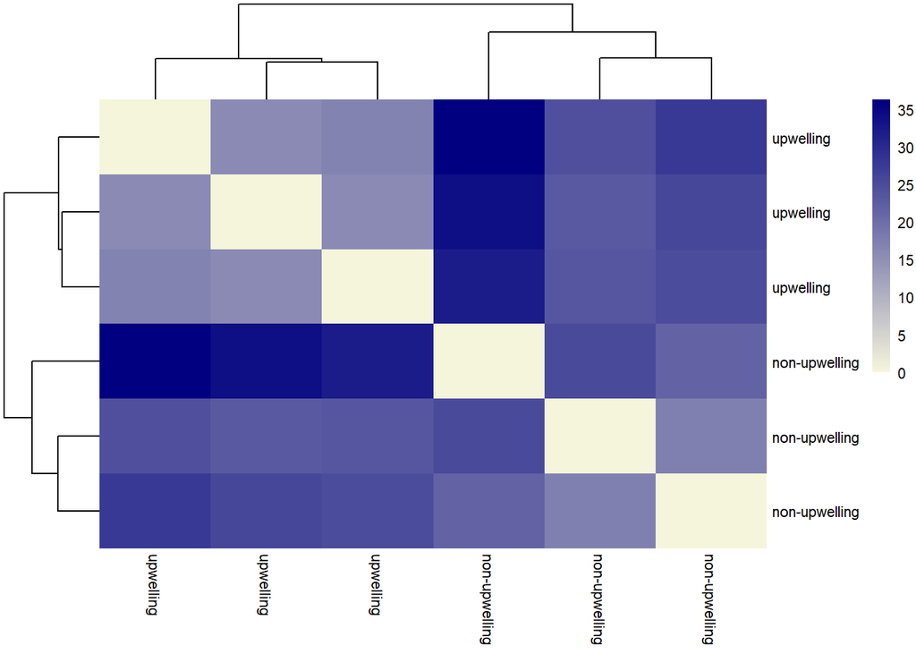

```r
rldpvals <- read.csv(file="RLDandPVALS.csv", row.names=1)
rld=rldpvals[,1:6]
#making rld which is just columns 1-6 and will cut off p-values to just leave us with r log normalized isogroups

sampleDists <- dist(t(rld))
sampleDistMatrix <- as.matrix( sampleDists )
treat=c( "upwelling", "upwelling", "upwelling", "non-upwelling", "non-upwelling", "non-upwelling")
colnames(sampleDistMatrix)=paste(treat)
rownames(sampleDistMatrix)=paste(treat)

#creating a heat map from the sampledistMatrix
heat.colors = colorRampPalette(rev(c("navy","beige")),bias=0.3)(100)
pheatmap(sampleDistMatrix,color = heat.colors,cex=0.9,border_color=NA,cluster_rows=T,cluster_cols=T)
```

# Principal Component Analysis

We then performed a principle components analysis (PCA). We first transposed our data frame and then removed columns within the dataframe with zero variance, meaning they were not diferentially expressed genes.

```r
rld_t=t(rld)

which(apply(rld_t, 2, var)==0)
rld_t <- rld_t[ , which(apply(rld_t, 2, var) != 0)]
```

We then created the PCA figure with ggplot. We are interested in PC1 and PC2 because these are the two principle components that explain the most variance in our samples.

```r
pca <- prcomp(rld_t,center = TRUE, scale. = TRUE) #up to 6 principle components because n=6 samples
head(pca)


#defining amount of variance described by PC1 and PC2
li <- pca$sdev^2 / sum(pca$sdev^2)
pc1v <- round(li[1] * 100, 1)
pc2v <- round(li[2] * 100, 1)
pca_s <- as.data.frame(pca$x)
head(pca_s)
pca_s <- pca_s[,c(1,2)] #pulling out first two PCs
pca_s$Samples = row.names(pca_s)
pca_s$treat=colData$treat
head(pca_s)
```

Here we plotted our PCA with ggplot:

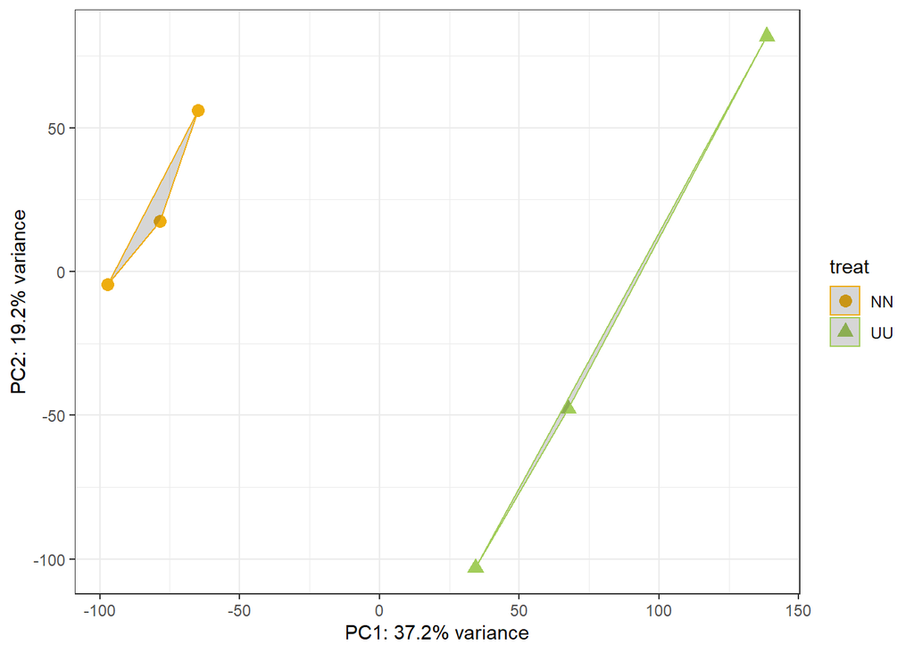

```r
cbPalette <- c("darkgoldenrod2",  "darkolivegreen3", "dodgerblue3")
ggplot(pca_s, aes(PC1, PC2, color = treat, pch = treat)) +
  geom_point(size=3) +
  #  geom_text_repel(aes(label=Samples)) +
  scale_colour_manual(values=cbPalette)+
  theme_bw() +
  # geom_density2d(alpha=.5)+
  geom_polygon(alpha=.2)+
  xlab(paste0("PC1: ",pc1v,"% variance")) +
  ylab(paste0("PC2: ",pc2v,"% variance"))
```

# Statistical Analysis

```r
adonis(pca$x ~ treat, data = pca_s, method='eu', na.rm = TRUE)
```

```
## 'nperm' >= set of all permutations: complete enumeration.
```

```
## Set of permutations < 'minperm'. Generating entire set.
```

```
##
## Call:
## adonis(formula = pca$x ~ treat, data = pca_s, method = "eu",      na.rm = TRUE)
##
## Permutation: free
## Number of permutations: 719
##
## Terms added sequentially (first to last)
##
##           Df SumsOfSqs MeanSqs F.Model      R2 Pr(>F)
## treat      1     41723   41723  2.1236 0.34678    0.1
## Residuals  4     78592   19648         0.65322
## Total      5    120315                 1.00000
```

# Heatmap

Here we are creating a heatmap for top 100 most significant differentially expressed genes.

```r
rldpvals <- read.csv(file="RLDandPVALS.csv", row.names=1)
head(rldpvals)
```

```
##                         NN       NN.1       NN.2         UU       UU.1
## SPU_016802      -1.9673957 -1.9754138 -1.9756254 -1.9753790 -1.9746116
## SPU_001114       0.7374181  0.7556454  0.7876164  0.6994910  0.7233684
## SPU_017127      -0.3993964 -0.3994176 -0.3458342 -0.3802686 -0.3766433
## SPU_017128       7.8420088  7.6647205  7.7827926  7.6397290  7.5735496
## ENSRNA022746508 -1.4982643 -1.4982983 -1.4986778 -1.4695371 -1.4968593
## SPU_023838       1.3969805  1.3966616  1.3755498  1.3411538  1.3685984
##                       UU.2   pval.UU   padj.UU
## SPU_016802      -1.9735944 0.8793810        NA
## SPU_001114       0.7042175 0.1175563        NA
## SPU_017127      -0.3971995 0.9022033        NA
## SPU_017128       7.4723371 0.0393330 0.1848653
## ENSRNA022746508 -1.4950345 0.6258252        NA
## SPU_023838       1.3806041 0.5437788 0.8035963
```

```r
rld_site= rldpvals[,1:6]
head(rld_site)
```

```
##                         NN       NN.1       NN.2         UU       UU.1
## SPU_016802      -1.9673957 -1.9754138 -1.9756254 -1.9753790 -1.9746116
## SPU_001114       0.7374181  0.7556454  0.7876164  0.6994910  0.7233684
## SPU_017127      -0.3993964 -0.3994176 -0.3458342 -0.3802686 -0.3766433
## SPU_017128       7.8420088  7.6647205  7.7827926  7.6397290  7.5735496
## ENSRNA022746508 -1.4982643 -1.4982983 -1.4986778 -1.4695371 -1.4968593
## SPU_023838       1.3969805  1.3966616  1.3755498  1.3411538  1.3685984
##                       UU.2
## SPU_016802      -1.9735944
## SPU_001114       0.7042175
## SPU_017127      -0.3971995
## SPU_017128       7.4723371
## ENSRNA022746508 -1.4950345
## SPU_023838       1.3806041
```

```r
gg=read.table("goAnnot_spu.tab",sep="\t", row.names=1)
head(gg)
```

```
##                                                     V2
## SPU_000002 GO:0007186;GO:0004930;GO:0005515;GO:0016021
## SPU_000005                       GO:0006259;GO:0004531
## SPU_000006            GO:0003676;GO:0004386;GO:0005524
## SPU_000007 GO:0007275;GO:0016055;GO:0005102;GO:0005576
## SPU_000008                       GO:0006629;GO:0008081
## SPU_000010                                  GO:0005634
```

```r
nrow(rldpvals[rldpvals$padj.UU<0.01& !is.na(rldpvals$padj.UU),])
```

```
## [1] 1344
```

We see here that 1344 isogroups are extremely differentially expressed at a p-adjusted value <0.01.

We ranked p-adjusted values to find the top 100 most differentially expressed genes.

```r
topnum= 100 # number of DEGS in final heatmap
head(rldpvals)
```

```
##                         NN       NN.1       NN.2         UU       UU.1
## SPU_016802      -1.9673957 -1.9754138 -1.9756254 -1.9753790 -1.9746116
## SPU_001114       0.7374181  0.7556454  0.7876164  0.6994910  0.7233684
## SPU_017127      -0.3993964 -0.3994176 -0.3458342 -0.3802686 -0.3766433
## SPU_017128       7.8420088  7.6647205  7.7827926  7.6397290  7.5735496
## ENSRNA022746508 -1.4982643 -1.4982983 -1.4986778 -1.4695371 -1.4968593
## SPU_023838       1.3969805  1.3966616  1.3755498  1.3411538  1.3685984
##                       UU.2   pval.UU   padj.UU
## SPU_016802      -1.9735944 0.8793810        NA
## SPU_001114       0.7042175 0.1175563        NA
## SPU_017127      -0.3971995 0.9022033        NA
## SPU_017128       7.4723371 0.0393330 0.1848653
## ENSRNA022746508 -1.4950345 0.6258252        NA
## SPU_023838       1.3806041 0.5437788 0.8035963
```

```r
top100=head(rldpvals[order(rldpvals$padj.UU), ],topnum)
head(top100)
```

```
##                   NN      NN.1      NN.2        UU      UU.1      UU.2
## SPU_015280  5.728884  5.793462  5.786773  7.916602  8.406507  8.408666
## SPU_026135  9.781368  9.968746  9.837049  8.520102  8.448695  8.450764
## SPU_007484 12.579483 12.635831 12.527725 13.551566 13.650424 13.729501
## SPU_017532  5.448669  5.581727  5.461893  7.456657  7.062319  7.828124
## SPU_015753  8.759779  8.836018  8.681240  7.624705  7.653573  7.629636
## SPU_025714  9.228341  9.342223  9.172497 10.172658 10.195341 10.320625
##                 pval.UU      padj.UU
## SPU_015280 3.858073e-68 7.152482e-64
## SPU_026135 1.058519e-64 9.811946e-61
## SPU_007484 2.869025e-54 1.772962e-50
## SPU_017532 6.097392e-44 2.825989e-40
## SPU_015753 2.062810e-37 7.648486e-34
## SPU_025714 2.749004e-35 8.493963e-32
```

```r
length(top100[,1])
```

```
## [1] 100
```

```r
summary(top100)
```

```
##        NN              NN.1             NN.2              UU
##  Min.   : 5.387   Min.   : 5.428   Min.   : 5.462   Min.   : 4.762
##  1st Qu.: 8.186   1st Qu.: 8.105   1st Qu.: 8.132   1st Qu.: 8.127
##  Median : 9.802   Median : 9.860   Median : 9.895   Median : 9.837
##  Mean   : 9.576   Mean   : 9.582   Mean   : 9.585   Mean   : 9.559
##  3rd Qu.:10.927   3rd Qu.:10.902   3rd Qu.:11.007   3rd Qu.:10.889
##  Max.   :13.916   Max.   :13.998   Max.   :13.887   Max.   :14.462
##       UU.1             UU.2           pval.UU             padj.UU
##  Min.   : 4.667   Min.   : 4.703   Min.   :0.000e+00   Min.   :0.000e+00
##  1st Qu.: 8.318   1st Qu.: 8.388   1st Qu.:5.200e-16   1st Qu.:3.750e-13
##  Median : 9.782   Median : 9.796   Median :3.408e-13   Median :1.249e-10
##  Mean   : 9.559   Mean   : 9.596   Mean   :1.509e-11   Mean   :3.167e-09
##  3rd Qu.:10.846   3rd Qu.:10.923   3rd Qu.:1.829e-11   3rd Qu.:4.506e-09
##  Max.   :14.575   Max.   :14.730   Max.   :1.200e-10   Max.   :2.225e-08
```

```r
head(top100)
```

```
##                   NN      NN.1      NN.2        UU      UU.1      UU.2
## SPU_015280  5.728884  5.793462  5.786773  7.916602  8.406507  8.408666
## SPU_026135  9.781368  9.968746  9.837049  8.520102  8.448695  8.450764
## SPU_007484 12.579483 12.635831 12.527725 13.551566 13.650424 13.729501
## SPU_017532  5.448669  5.581727  5.461893  7.456657  7.062319  7.828124
## SPU_015753  8.759779  8.836018  8.681240  7.624705  7.653573  7.629636
## SPU_025714  9.228341  9.342223  9.172497 10.172658 10.195341 10.320625
##                 pval.UU      padj.UU
## SPU_015280 3.858073e-68 7.152482e-64
## SPU_026135 1.058519e-64 9.811946e-61
## SPU_007484 2.869025e-54 1.772962e-50
## SPU_017532 6.097392e-44 2.825989e-40
## SPU_015753 2.062810e-37 7.648486e-34
## SPU_025714 2.749004e-35 8.493963e-32
```

```r
p.val=0.1 # FDR cutoff
conds=top100[top100$padj.UU<=p.val & !is.na(top100$padj.UU),] #all top 100 where the p- adjusted value is less than or equal to .1 (significant)
length(conds[,1])
```

```
## [1] 100
```

```r
exp=conds[,1:6] #removing associated p-values from log fold change data
means=apply(exp,1,mean) # means of rows
explc=exp-means # subtracting them
colnames(explc)=c("NN1", "NN2", "NN3", "UU1", "UU2", "UU3")
head(explc)
```

```
##                   NN1        NN2        NN3        UU1        UU2        UU3
## SPU_015280 -1.2779314 -1.2133539 -1.2200428  0.9097865  1.3996911  1.4018506
## SPU_026135  0.6135802  0.8009586  0.6692616 -0.6476855 -0.7190919 -0.7170230
## SPU_007484 -0.5329386 -0.4765907 -0.5846969  0.4391446  0.5380021  0.6170795
## SPU_017532 -1.0245625 -0.8915049 -1.0113384  0.9834258  0.5890874  1.3548926
## SPU_015753  0.5622875  0.6385263  0.4837482 -0.5727869 -0.5439192 -0.5678559
## SPU_025714 -0.5102734 -0.3963909 -0.5661176  0.4340439  0.4567272  0.5820107
```

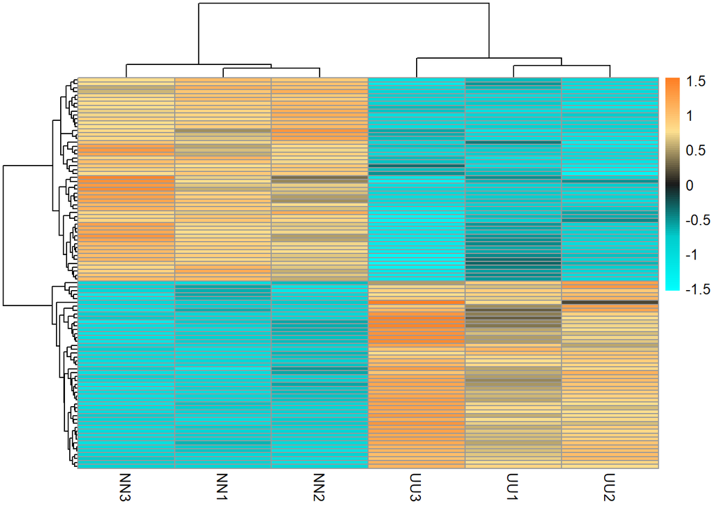

```r
ccol=colorRampPalette(rev(c("red","chocolate1","#FEE090","grey10", "cyan3","cyan")))(100)
col0=colorRampPalette(rev(c("chocolate1","#FEE090","grey10", "cyan3","cyan")))(100)

pheatmap(explc,cluster_cols=T,scale="row",color=col0, show_rownames = F)
```

We then added gene annotation to top 100 heatmap.

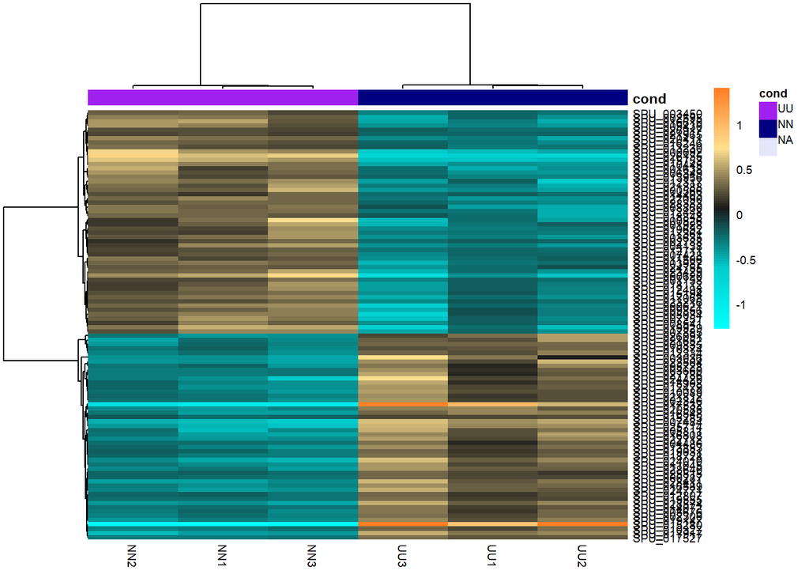

```r
ann = data.frame(cond = c('UU', 'UU', 'UU', 'NN', 'NN', 'NN'))
rownames(ann) <- names(explc)

# Set colors
Var1        <- c("purple",  "Navy", "Lavender")
names(Var1) <- c("UU", "NN")
anno_colors <- list(cond = Var1)

pheatmap(as.matrix(explc),annotation_col=ann,annotation_colors=anno_colors,cex=.85,color=col0,border_color=NA,clustering_distance_rows="correlation",clustering_distance_cols="correlation", show_rownames=T)
```

# GO Analysis

For our GO analysis, we started with assigning variables for gomwuStats arguments and inputted the files we generated above.

```r
input="UU_GO.csv" #isogroup with corresponding p-value
goAnnotations="goAnnot_spu.tab"
goDatabase="go-basic.obo"
source("gomwu.functions.R") #reading in code for functions needed to enact GO analysis
```

# GO Statistics

```r
#GO terms under Biological Process

goDivision.BP="BP" #change and run GO for each major functional group (BP, MF, CC)

gomwuStats(input, goDatabase, goAnnotations, goDivision.BP, perlPath = "perl",
           largest=0.1, # setting maximum proportion of total genes before GO terms not represented
           smallest=5, # setting minimum number of different genes needed under a GO term to be represented
           clusterCutHeight=0.25 #setting specificity of represented GO terms #Increase for more specificity #decrease for more general umbrella terms)
)
```

```
## Continuous measure of interest: will perform MWU test
## 64  GO terms at 10% FDR
```

```r
#Largest and smallest set to define reasonable levels of enrichment
```

```r
#GO terms under Cellular Component

goDivision.CC="CC" #change and run GO for each major functional group (BP, MF, CC)

gomwuStats(input, goDatabase, goAnnotations, goDivision.CC, perlPath = "perl", largest=0.1, smallest=5, clusterCutHeight=0.25)
```

```
## Continuous measure of interest: will perform MWU test
## 7  GO terms at 10% FDR
```

```r
#GO terms under Molecular Function

goDivision.MF="MF" #change and run GO for each major functional group (BP, MF, CC)

gomwuStats(input, goDatabase, goAnnotations, goDivision.MF, perlPath = "perl", largest=0.1, smallest=5, clusterCutHeight=0.25)
```

```
## Continuous measure of interest: will perform MWU test
## 46  GO terms at 10% FDR
```

# Plotting GO terms

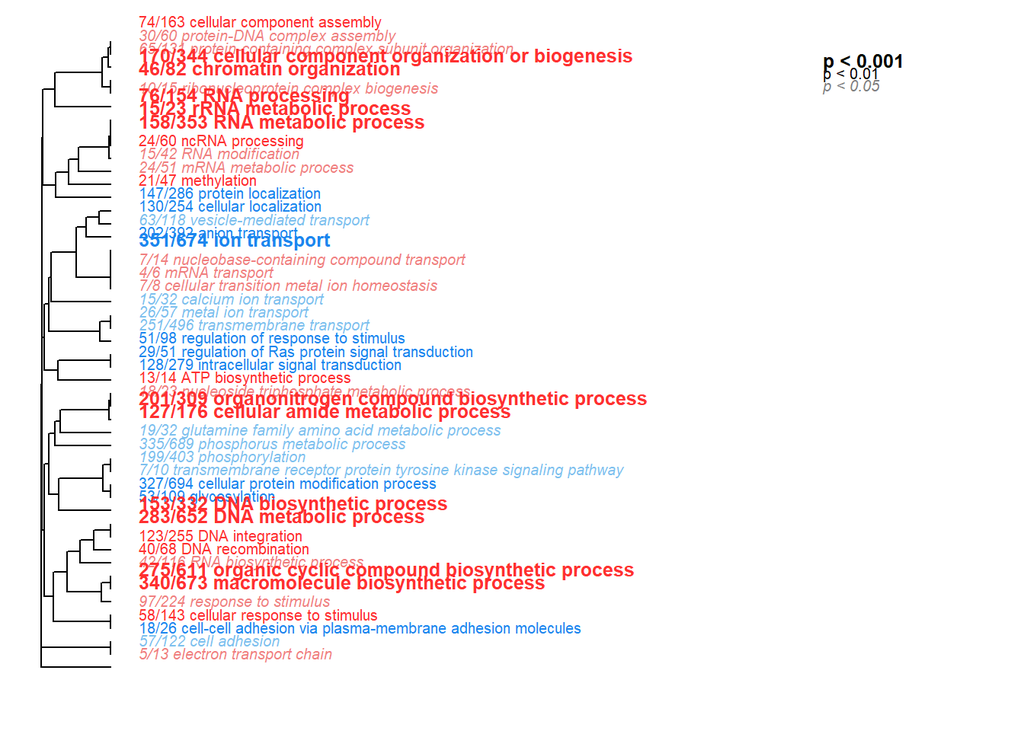

```
## GO terms dispayed:  49
## "Good genes" accounted for:  1888 out of 3015 ( 63% )
```

```r
#BP

#quartz() #hash out if on windows
results=gomwuPlot(input,goAnnotations,goDivision.BP,
    absValue=-log(0.05,10),
    level1=0.05, # 1st Threshold for plotting.
    level2=0.01, # Each level represents greater signficance
    level3=0.001,
    txtsize=1.2,
    treeHeight=0.5, # height of the hierarchical clustering tree
    colors=c("dodgerblue2","firebrick1","skyblue2","lightcoral")
)
```

```r
#restricted cutoffs to reduce number of GO categories displayed
```

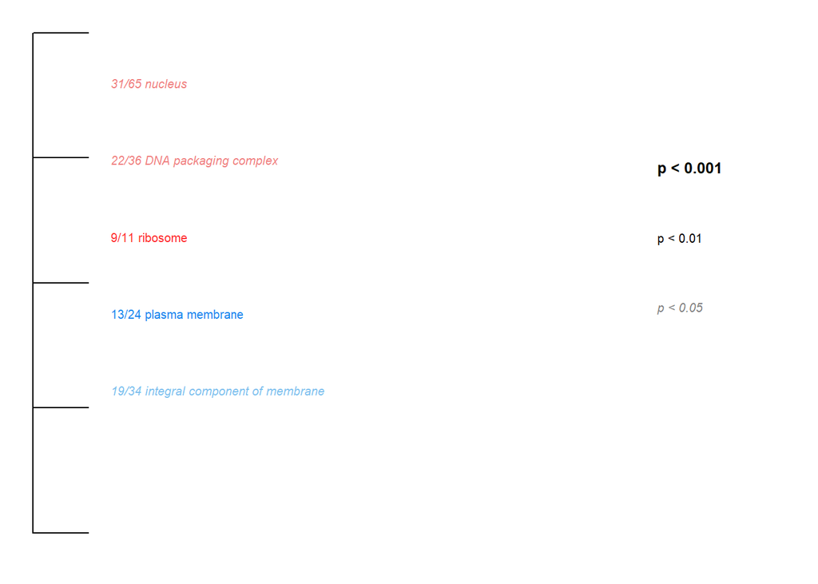

```
## GO terms dispayed:  5
## "Good genes" accounted for:  94 out of 215 ( 44% )
```

```r
#CC

#quartz()
results=gomwuPlot(input,goAnnotations,goDivision.CC,
    absValue=-log(0.05,10),
    level1=0.05,
    level2=0.01,
    level3=0.001,
    txtsize=1.2,
    treeHeight=0.5,
    colors=c("dodgerblue2","firebrick1","skyblue2","lightcoral")
)
```

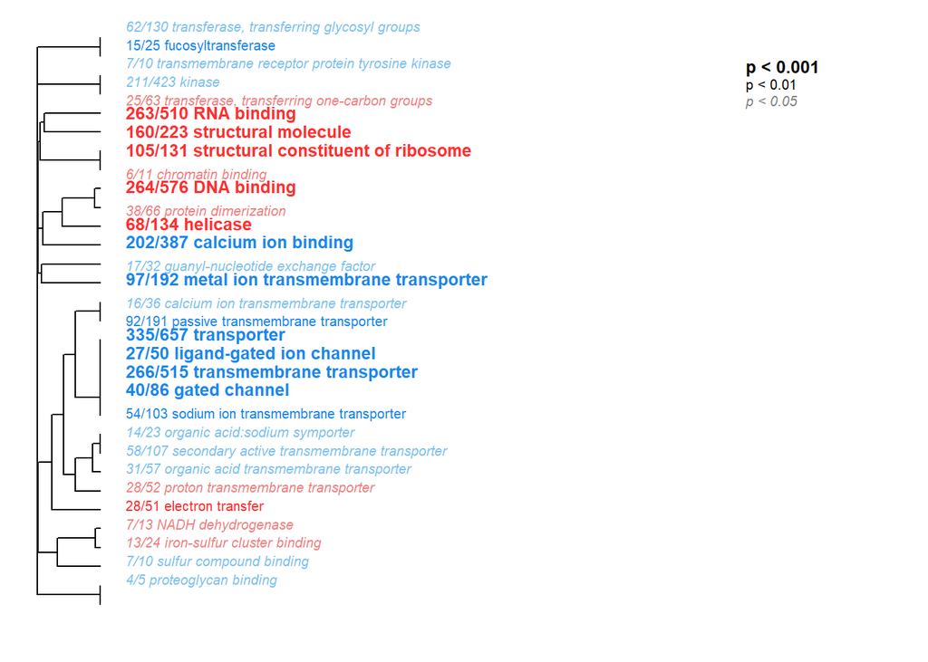

```
## GO terms dispayed:  31
## "Good genes" accounted for:  1591 out of 2799 ( 57% )
```

```r
#MF

#quartz()
results=gomwuPlot(input,goAnnotations,goDivision.MF,
    absValue=-log(0.05,10),
    level1=0.05,
    level2=0.01,
    level3=0.001,
    txtsize=1.2,
    treeHeight=0.5,
    colors=c("dodgerblue2","firebrick1","skyblue2","lightcoral")
)
```